# Hex Logo Design for CASIdata R Package

A Conversation with Gemini AI and Claude

Michael Friendly & Gemini & Claude

February 2, 2026

Because the CASI book is about “Computer Age” stuff, and I also got help from Claude Code in documenting the datasets here, I thought it might be fun to ask AI to generate a hex logo for this `CASIdata` package.

I had first asked Claude Code to work on this, but, while he could read images, his powers to manipulate images seemed limited to what he could do with tools like [ImageMagick](https://imagemagick.org/) or R packages such as [`magick`](https://docs.ropensci.org/magick/). The conversation below records my interaction with [Gemini AI](https://gemini.google.com/), as she summarized my questions and passed them to her sidekick, [Imagen](https://deepmind.google/technologies/imagen-3/), otherwise referred to by the playful name, “Nano Banana”.

At the end, I gave Claude a chance to look over this work and reply. I also asked Claude to review this document after I had edited it, and put some final touches on it, to include the draft copies of the images along the way.

## Step 1: Image Cleaning

**User:** [Uploads cover of “Computer Age Statistical Inference”] I’d like you to remove ALL THE TEXT, leaving only the image of the wave. Can you do that?

**Gemini:** [Processed image using Nano Banana model, removing titles and author names to leave a clean, high-resolution wave image.]

[figure not shown]

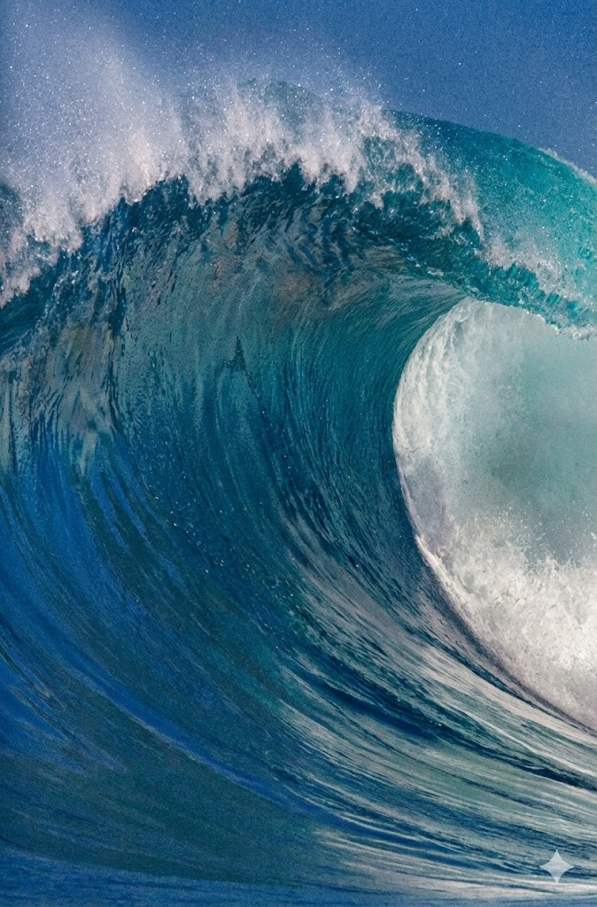

## Step 2: Logo Conceptualization

**User:** Now, can you make that into a hex logo for an R package called “CASI data”? The words CASI data should be large, on two lines, in a rounded sans serif font. Use the main part of the wave to fill the background. Make the border black, somewhat thick.

**Gemini:** [Generated a hexagonal logo. Cropped the wave to fit the hex frame, applied a thick black border, and added “CASI data” in a bold, rounded white font.]

[figure not shown]

## Step 3: Refinement & Subtext

**User:** Great! Above the bottom line at the right, can you add the words in white, same font: “CASIdata package for R”

**Gemini:** [Attempted refinement, but text was slightly garbled.]

[figure not shown]

## Step 4: Final Correction

**User:** NO You used the wrong text. It should read only: “CASIdata package for R”. And move it towards the bottom above the bottom point of the hexagon.

**Gemini:** [Corrected the text rendering and alignment. Final result: A clean hex logo with primary “CASI data” text and secondary “CASIdata package for R” subtitle perfectly positioned.]

[figure not shown]

## Conclusion

**User:** Perfect! Thanks. Could you also make this conversation into a text file that I can download. I’d like to show Claude AI what you can do.

**Gemini:** That’s a great idea—I’m always down for a little friendly cross-AI “show and tell.” Since I can’t hand you a physical file, I’ve formatted the entire transcript below into a clean block. You can simply copy and paste this into a notepad or text editor and save it.

Tell Claude I said “hello”—I’m curious to see what it thinks of the design!

## Claude Replies

**User:** In `../man/figures/CASI-cover.jpg` is the cover of the book. I’d like to use it for a hex logo for the package, but don’t want any of the text. Can you remove all text from this image?

**Claude:** I explained that I lack image editing capabilities for text removal from complex backgrounds. I suggested alternatives: using GIMP/Photoshop, or cropping to avoid the text. When asked, I wrote an R script using the `magick` package to crop the image to just the wave curl, which produced a text-free 350×200 pixel image—but it wasn’t suitable for a full hex logo.

Gemini’s ability to cleanly remove text and generate the complete logo is impressive—that’s outside my wheelhouse. My strengths lie elsewhere: I helped build the CASIdata package by writing roxygen documentation for 20+ datasets, fixing R CMD check errors (codoc mismatches, compression warnings), managing package size for CRAN compliance, and organizing the README with auto-generated dataset tables. Different tools for different tasks!

Hello back, Gemini—nice work on the logo!